# Stat420FinalProjectJulia

Julia Dawson

8/3/2020

## Stat 420: Final Project

Data is from https://www.countyhealthrankings.org/explore-health-rankings/rankings-data-documentation.

## Test Statistics that we used:

**adjusted R-squared** is a modified version of R-squared that has been adjusted for the number of predictors in the model. The adjusted R-squared increases only if the new term improves the model more than would be expected by chance. It decreases when a predictor improves the model by less than expected by chance.

**LOOCV RMSE**: leave-one out cross-validated RMSE allows us to check for overfitting.

**Correlation Coefficients** **Partial Correlation Coefficients**

**Shapiro-Wilk Test**: Shapiro test assesses the normality of errors. The null hypothesis assumes data were sampled from a normal distribution. A small p-value rejects the null hypothesis.

**Breusch-Pagan-Godfrey Test**: https://www.statisticshowto.com/breusch-pagan-godfrey-test/ Heteroscedastic data. … Heteroscedasticity means “differently scattered”; this is opposite to homoscedastic, which means “same scatter.” Homoscedasticity in regression is an important assumption; if the assumption is violated, you won’t be able to use regression analysis. If bptest gives a very small p-value so we reject the null hypothesis of constant variance.

**Durbin-Watson**: https://www.statisticshowto.com/durbin-watson-test-coefficient dwtest p — p-value of test p-value of the test, returned as a numeric value. dwtest tests whether the residuals are uncorrelated, against the alternative that autocorrelation exists among the residuals. A small p-value indicates that the residuals are autocorrelated. 0 to < 2 is positive autocorrelation. >2 to 4 is negative autocorrelation. Test statistics between 1.5 and 2.5 are relatively normal. The null hypothesis for dwtest is no first order correlation exists. Our p-value is higher than alpha 0.05 so we cannot reject the null hypothesis.

## Model Search:

```
## State, Region, FIPS, Deaths, YPLLRate, HealthPoorPct, HealthBadDaysPhysAvg, HealthBadDaysMentAvg, LBWPct, SmokersPct, ObeseAdultsPct, FoodEnvirIX, PhysInactPct, ExerAccPct, DrinkExcPct, DeathsDrinkDrivePct, ChlamydiaRate, TeenBirthRate, UninsuredPct, PhysPrimCareRate, DentistRate, MentHProvRate, …
```

```
## 71 data elements have NA counts below the threshhold of  294
```

```
## Raw95: Has  90  columns and  3142  rows.
```

```
## Raw95: Has  21510  NA at rate  0.0760661998726926
```

```
## Raw95naomit: Dropped high na columns, omitted rows with NA, have  71  columns and  2333  rows.
```

```
## Raw95naomit: Has  0  NA at rate  0
```

## Modeling the Data (Part1): Things that were tried:

- Additive model predictors with highest correlation to response (*mdlhicorr1*).
- Drop one by one those with highest p-values (*mdlhicorr2*).

**Additive Model with all high correlation data elements (mdlhicorr1):**

```r
formula(mdlhicorr1)
```

```
## YPLLRate ~ ChlamydiaRate + CollegeSomePct + DeathAgeAdjRate +
##     DistressFreqMentPct + DriveAloneWorkPct + FIPS + HealthBadDaysMentAvg +
##     HospPrevRate + Income20thpcntl + IncomeRatio + InjuryDeathRate +
##     LBWPct + LifeExpect + MammAnnualPct + PhysInactPct + PhysPrimCareRate +
##     PopGE65Pct + PopRuralPct + SingsParsHshsldsPct + SmokersPct +
##     UnemployedPct + UninsAdultPct + VaccinatedPct
```

- adjusted-Rsquared: 0.9556921
- loocv-RMSE: 503.8891559
- number of coef: 24
- Shapiro: 0.9680541, 2.336039410^{-22}, Shapiro-Wilk normality test, resid(mdlhicorr1)
- Durbin-Watson: 1.8561958, Durbin-Watson test, true autocorrelation is greater than 0, 1.532090310^{-4}, mdlhicorr1
- bptest: 343.8244978, 23, studentized Breusch-Pagan test, 5.778994110^{-59}, mdlhicorr1

**Above Model high prob predictors removed and interactions added (mdlhicorr2):**

```r
formula(mdlhicorr2)
```

```
## YPLLRate ~ (ChlamydiaRate + CollegeSomePct + DeathAgeAdjRate +
##     DistressFreqMentPct + DriveAloneWorkPct + FIPS + HealthBadDaysMentAvg +
##     HospPrevRate + Income20thpcntl + IncomeRatio + InjuryDeathRate +
##     LBWPct + LifeExpect + MammAnnualPct + PhysInactPct + PhysPrimCareRate +
##     PopGE65Pct + PopRuralPct + SingsParsHshsldsPct + SmokersPct +
##     UnemployedPct + UninsAdultPct + VaccinatedPct) - HealthBadDaysMentAvg -
##     HospPrevRate - Income20thpcntl - MammAnnualPct - PhysPrimCareRate -
##     SmokersPct + DeathAgeAdjRate:HealthBadDaysMentAvg + DeathAgeAdjRate:Income20thpcntl +
##     DeathAgeAdjRate:LifeExpect
```

- adjusted-Rsquared: 0.9562047
- loocv-RMSE: 501.5361045
- number of coef: 21
- Shapiro: 0.9664506, 6.82769610^{-23}, Shapiro-Wilk normality test, resid(mdlhicorr2)
- Durbin-Watson: 1.8404433, Durbin-Watson test, true autocorrelation is greater than 0, 3.569833910^{-5}, mdlhicorr2
- bptest: 432.0908465, 20, studentized Breusch-Pagan test, 4.387292710^{-79}, mdlhicorr2

**Additive all (mdl3):**

```r
formula(mdl3)
```

```
## YPLLRate ~ State + Region + FIPS + Deaths + HealthPoorPct + HealthBadDaysPhysAvg +
##     HealthBadDaysMentAvg + LBWPct + SmokersPct + ObeseAdultsPct +
##     FoodEnvirIX + PhysInactPct + ExerAccPct + DrinkExcPct + DeathsDrinkDrivePct +
##     ChlamydiaRate + TeenBirthRate + UninsuredPct + PhysPrimCareRate +
##     DentistRate + MentHProvRate + HospPrevRate + MammAnnualPct +
##     VaccinatedPct + HSGradRate + Population + CollegeSomePct +
##     LaborForce + UnemployedPct + ChildInPovertyPct + Income80thpcntl +
##     Income20thpcntl + IncomeRatio + SingsParsHshsldsPct + SocsAssRate +
##     ViolsCrimeAnlAvg + ViolCrimeRate + InjuryDeathRate + DailyPM25Avg +
##     WaterViol + HousSvrProbPct + HousSvrCostBurden + HousSvrOvercrowd +
##     HousInadFacil + DriveAloneWorkPct + DriveAloneLongPct + LifeExpect +
##     DeathAgeAdjRate + DistressFreqPhysPct + DistressFreqMentPct +
##     DiabetesAdultPct + FoodInsecurePct + FoodHealthLimAccPct +
##     SleepPoorPct + UninsAdultPct + UninsChildPct + OthPrimCareProvRate +
##     IncHousehldMedian + LunchFreeReducedPct + TrafficVolume +
##     HomeownersPct + HousehldSvrCostPct + Population2 + PopLT18Pct +
##     PopGE65Pct + PopNativePct + PopPacificPct + EnglishNotProfPct +
##     PopFemalePct + PopRuralPct
```

- adjusted-Rsquared: 0.9611707
- loocv-RMSE:
- number of coef: 1564(Note: State adds 51, Region would add 3142)
- Shapiro: 0.8287729, 1.575254910^{-44}, Shapiro-Wilk normality test, resid(mdl3)
- Durbin-Watson: 2.0325457, Durbin-Watson test, true autocorrelation is greater than 0, 0.470823, mdl3
- bptest: 1068.3827659, 1563, studentized Breusch-Pagan test, 1, mdl3

**Additive all, back AIC (mdl4):**

```r
formula(mdl4)
```

```
## YPLLRate ~ State + HealthBadDaysMentAvg + LBWPct + FoodEnvirIX +
##     PhysInactPct + DeathsDrinkDrivePct + ChlamydiaRate + UninsuredPct +
##     PhysPrimCareRate + HospPrevRate + MammAnnualPct + VaccinatedPct +
##     Population + CollegeSomePct + Income20thpcntl + IncomeRatio +
##     SocsAssRate + InjuryDeathRate + DailyPM25Avg + HousSvrProbPct +
##     HousSvrCostBurden + HousSvrOvercrowd + HousInadFacil + DriveAloneWorkPct +
##     DriveAloneLongPct + LifeExpect + DeathAgeAdjRate + DistressFreqMentPct +
##     UninsAdultPct + IncHousehldMedian + Population2 + PopGE65Pct +
##     PopNativePct + PopPacificPct + EnglishNotProfPct + PopFemalePct +
##     PopRuralPct
```

- adjusted-Rsquared: 0.9632989
- loocv-RMSE: 464.8485936
- number of coef: 81(Note: State adds 51, Region would add 3142)
- Shapiro: 0.9780353, 1.704268110^{-18}, Shapiro-Wilk normality test, resid(mdl4)
- Durbin-Watson: 2.040922, Durbin-Watson test, true autocorrelation is greater than 0, 0.5360836, mdl4
- bptest: 412.1847091, 80, studentized Breusch-Pagan test, 3.346291310^{-46}, mdl4

**Additive all, back AIC, remove high pval (mdl5):**

```r
formula(mdl5)
```

```
## YPLLRate ~ State + HealthBadDaysMentAvg + LBWPct + LBWPct + FoodEnvirIX +
##     PhysInactPct + DeathsDrinkDrivePct + ChlamydiaRate + log(UninsuredPct) +
##     I(PhysPrimCareRate^2) + I(HospPrevRate^2) + MammAnnualPct +
##     VaccinatedPct + Population + CollegeSomePct + Income20thpcntl +
##     IncomeRatio + SocsAssRate + InjuryDeathRate + DailyPM25Avg +
##     HousSvrProbPct + HousSvrCostBurden + HousSvrOvercrowd + HousInadFacil +
##     DriveAloneWorkPct + DriveAloneLongPct + LifeExpect + DeathAgeAdjRate +
##     DistressFreqMentPct + log(UninsAdultPct) + I(IncHousehldMedian^2) +
##     Population2 + PopGE65Pct + PopNativePct + PopPacificPct +
##     EnglishNotProfPct + PopFemalePct + PopRuralPct + PopGE65Pct:DeathAgeAdjRate +
##     PopFemalePct:DistressFreqPhysPct
```

- adjusted-Rsquared: 0.9638106
- loocv-RMSE: 461.6131412
- number of coef: 83(Note: State adds 51, Region would add 3142)
- Shapiro: 0.9789549, 4.441306810^{-18}, Shapiro-Wilk normality test, resid(mdl5)
- Durbin-Watson: 2.041566, Durbin-Watson test, true autocorrelation is greater than 0, 0.5428095, mdl5
- bptest: 439.8338894, 82, studentized Breusch-Pagan test, 2.27323610^{-50}, mdl5

## Modeling the Data (Part 2): Things that were tried:

```
## [1] 160
```

```
## Influential observations: there were  160  observations that were influential to model 6. Removing them dropped RMSE significantly.
```

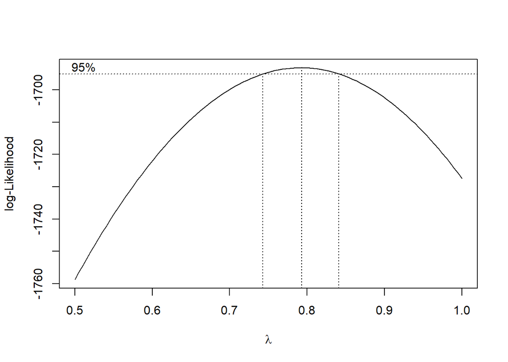

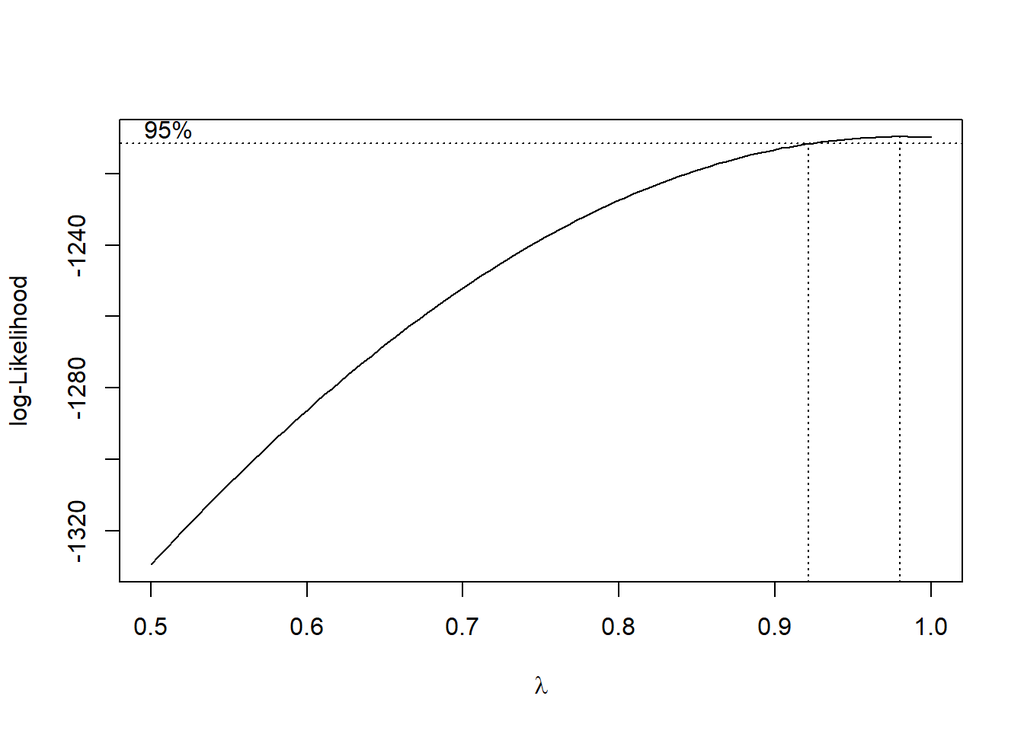

```
##
## Call:
## lm(formula = YPLLRate^lmda ~ HealthPoorPct + FoodEnvirIX + PhysInactPct +
##     PhysPrimCareRate + MammAnnualPct + Income20thpcntl + IncomeRatio +
##     SocsAssRate + InjuryDeathRate + HousSvrProbPct + HousInadFacil +
##     LifeExpect + DeathAgeAdjRate + VaccinatedPct + IncHousehldMedian +
##     PopGE65Pct + PopNativePct + PopPacificPct + EnglishNotProfPct +
##     PopRuralPct + PopGE65Pct:DeathAgeAdjRate + HealthPoorPct:PopFemalePct +
##     LBWPct:IncHousehldMedian, data = Raw95naomit, subset = cdnaomit <=
##     4/length(cdnaomit))
##
## Residuals:
##      Min       1Q   Median       3Q      Max
## -171.494  -32.643   -0.293   32.013  166.202
##
## Coefficients:
##                              Estimate Std. Error t value Pr(>|t|)
## (Intercept)                 2.732e+03  1.666e+02  16.399  < 2e-16 ***
## HealthPoorPct              -8.800e+00  1.736e+00  -5.069 4.35e-07 ***
## FoodEnvirIX                -1.310e+01  2.005e+00  -6.531 8.12e-11 ***
## PhysInactPct               -1.548e+00  2.911e-01  -5.319 1.15e-07 ***
## PhysPrimCareRate           -1.219e-01  4.187e-02  -2.912 0.003630 **
## MammAnnualPct               1.121e+00  2.160e-01   5.190 2.30e-07 ***
## Income20thpcntl             6.209e-03  7.873e-04   7.887 4.88e-15 ***
## IncomeRatio                 1.168e+01  3.219e+00   3.628 0.000293 ***
## SocsAssRate                -1.238e+00  2.832e-01  -4.370 1.30e-05 ***
## InjuryDeathRate             1.534e+00  8.226e-02  18.644  < 2e-16 ***
## HousSvrProbPct              2.495e+00  4.238e-01   5.887 4.54e-09 ***
## HousInadFacil              -4.389e+00  1.592e+00  -2.757 0.005875 **
## LifeExpect                 -3.040e+01  1.915e+00 -15.875  < 2e-16 ***
## DeathAgeAdjRate             1.619e+00  7.411e-02  21.846  < 2e-16 ***
## VaccinatedPct               3.764e-01  1.602e-01   2.350 0.018874 *
## IncHousehldMedian          -3.375e-03  3.618e-04  -9.328  < 2e-16 ***
## PopGE65Pct                  3.019e+00  1.089e+00   2.773 0.005605 **
## PopNativePct                3.308e+00  2.599e-01  12.728  < 2e-16 ***
## PopPacificPct              -2.386e+01  5.886e+00  -4.054 5.22e-05 ***
## EnglishNotProfPct           2.646e+00  6.233e-01   4.246 2.27e-05 ***
## PopRuralPct                 2.674e-01  5.783e-02   4.624 3.99e-06 ***
## DeathAgeAdjRate:PopGE65Pct  7.690e-03  2.691e-03   2.857 0.004314 **
## HealthPoorPct:PopFemalePct  1.991e-01  3.227e-02   6.169 8.17e-10 ***
## IncHousehldMedian:LBWPct    2.391e-04  1.725e-05  13.857  < 2e-16 ***
## ---
## Signif. codes:  0 '***' 0.001 '**' 0.01 '*' 0.05 '.' 0.1 ' ' 1
##
## Residual standard error: 49.45 on 2149 degrees of freedom
## Multiple R-squared:  0.9721, Adjusted R-squared:  0.9718
## F-statistic:  3250 on 23 and 2149 DF,  p-value: < 2.2e-16
```

**mdl6: Additive Model with enhancements, before removal of influential obs:**

```r
formula(mdl6)
```

```
## YPLLRate ~ State + HealthBadDaysMentAvg + LBWPct + LBWPct + FoodEnvirIX +
##     PhysInactPct + DeathsDrinkDrivePct + ChlamydiaRate + log(UninsuredPct) +
##     I(PhysPrimCareRate^2) + I(HospPrevRate^2) + MammAnnualPct +
##     VaccinatedPct + Population + CollegeSomePct + Income20thpcntl +
##     IncomeRatio + SocsAssRate + InjuryDeathRate + DailyPM25Avg +
##     HousSvrProbPct + HousSvrCostBurden + HousSvrOvercrowd + HousInadFacil +
##     DriveAloneWorkPct + DriveAloneLongPct + LifeExpect + DeathAgeAdjRate +
##     DistressFreqMentPct + log(UninsAdultPct) + I(IncHousehldMedian^2) +
##     Population2 + PopGE65Pct + PopNativePct + PopPacificPct +
##     EnglishNotProfPct + PopFemalePct + PopRuralPct + PopGE65Pct:DeathAgeAdjRate +
##     PopFemalePct:DistressFreqPhysPct
```

- adjusted-Rsquared: 0.9638106 **Good predictive model fit**
- loocv-RMSE: 461.6131412 **Bad: should be less than StdDev(YPLLRate) 2367.2590348**
- number of coef: 83(Note: State adds 51)
- Shapiro: 4.441306810^{-18} **Poor: p-value below alpha 0.05 rejects normality assumption**
- Durbin-Watson: 2.041566, Durbin-Watson test, true autocorrelation is greater than 0, 0.5428095, mdl6 **Good: higher p-value so cannot reject null hypothesis residuals are uncorrelated.**
- bptest: 439.8338894, 82, studentized Breusch-Pagan test, 2.27323610^{-50}, mdl6 **BAD: small p-value means non-constant variance**

**mdl6fix: Additive Model with enhancements,after remove influential obs:**

```r
formula(mdl6fix)
```

```
## YPLLRate ~ State + HealthBadDaysMentAvg + LBWPct + LBWPct + FoodEnvirIX +
##     PhysInactPct + DeathsDrinkDrivePct + ChlamydiaRate + log(UninsuredPct) +
##     I(PhysPrimCareRate^2) + I(HospPrevRate^2) + MammAnnualPct +
##     VaccinatedPct + Population + CollegeSomePct + Income20thpcntl +
##     IncomeRatio + SocsAssRate + InjuryDeathRate + DailyPM25Avg +
##     HousSvrProbPct + HousSvrCostBurden + HousSvrOvercrowd + HousInadFacil +
##     DriveAloneWorkPct + DriveAloneLongPct + LifeExpect + DeathAgeAdjRate +
##     DistressFreqMentPct + log(UninsAdultPct) + I(IncHousehldMedian^2) +
##     Population2 + PopGE65Pct + PopNativePct + PopPacificPct +
##     EnglishNotProfPct + PopFemalePct + PopRuralPct + PopGE65Pct:DeathAgeAdjRate +
##     PopFemalePct:DistressFreqPhysPct
```

- adjusted-Rsquared: 0.9753082 **Good predictive model fit**
- loocv-RMSE: 357.6242397 **Improved: should be less than StdDev(YPLLRate) 2367.2590348**
- number of coef: 83(Note: State adds 51, Region would add 3142)
- Shapiro: 3.199519810^{-5} **Poor: p-value below alpha 0.05 rejects normality assumption**
- Durbin-Watson: 2.0386718, Durbin-Watson test, true autocorrelation is greater than 0, 0.492023, mdl6fix **Good: higher p-value so cannot reject null hypothesis residuals are uncorrelated.**
- bptest: 250.782429, 82, studentized Breusch-Pagan test, 5.331894910^{-19}, mdl6fix **small p-value means non-constant variance**

**Removing influential observations improved LOOCV RMSE by 22.5272836 percent.**

**mdl7fix: Additive Model with enhancements, best LOOCV RMSE score so far:**

```r
formula(mdl7fix)
```

```
## YPLLRate ~ State + FIPS + HealthPoorPct + HealthBadDaysMentAvg +
##     ObeseAdultsPct + FoodEnvirIX + PhysInactPct + DeathsDrinkDrivePct +
##     ChlamydiaRate + TeenBirthRate + log(UninsuredPct) + PhysPrimCareRate +
##     HospPrevRate + MammAnnualPct + VaccinatedPct + Population +
##     CollegeSomePct + Income20thpcntl + IncomeRatio + SocsAssRate +
##     ViolCrimeRate + InjuryDeathRate + DailyPM25Avg + HousSvrProbPct +
##     HousSvrCostBurden + HousSvrOvercrowd + HousInadFacil + LifeExpect +
##     DeathAgeAdjRate + FoodHealthLimAccPct + log(UninsAdultPct) +
##     IncHousehldMedian + Population2 + PopGE65Pct + PopNativePct +
##     PopPacificPct + EnglishNotProfPct + PopRuralPct + PopGE65Pct:DeathAgeAdjRate +
##     HealthPoorPct:PopLT18Pct + HealthPoorPct:PopFemalePct + HealthBadDaysMentAvg:DeathAgeAdjRate +
##     LBWPct:IncHousehldMedian
```

- adjusted-Rsquared: 0.9756216 **Good predictive model fit**
- loocv-RMSE: 355.8300767 **Poor: should be less than StdDev(YPLLRate) 2367.2590348**
- number of coef: 87(Note: State adds 51, Region would add 3142)
- Shapiro: 1.257966510^{-4} **Poor: p-value below alpha 0.05 rejects normality assumption**
- Durbin-Watson: 2.0301738, Durbin-Watson test, true autocorrelation is greater than 0, 0.4052217, mdl7fix **Good: higher p-value so cannot reject null hypothesis residuals are uncorrelated.**
- bptest: 263.7804476, 86, studentized Breusch-Pagan test, 6.114665210^{-20}, mdl7fix **small p-value means non-constant variance**

**mdl8: Additive Model with enhancements, smaller model:**

```r
formula(mdl8)
```

```
## YPLLRate ~ State + HealthPoorPct + HealthBadDaysMentAvg + FoodEnvirIX +
##     PhysInactPct + PhysPrimCareRate + MammAnnualPct + VaccinatedPct +
##     CollegeSomePct + Income20thpcntl + IncomeRatio + SocsAssRate +
##     InjuryDeathRate + HousSvrProbPct + HousInadFacil + LifeExpect +
##     DeathAgeAdjRate + FoodHealthLimAccPct + log(UninsAdultPct) +
##     IncHousehldMedian + PopGE65Pct + PopNativePct + PopPacificPct +
##     EnglishNotProfPct + PopRuralPct + PopGE65Pct:DeathAgeAdjRate +
##     HealthPoorPct:PopFemalePct + LBWPct:IncHousehldMedian
```

**mdl10: Additive Model with enhancements, smaller model, scaled Result and Predictors and without State:**

```r
formula(mdl10)
```

```
## YPLLRate ~ HealthPoorPct + HealthBadDaysMentAvg + FoodEnvirIX +
##     PhysInactPct + PhysPrimCareRate + MammAnnualPct + VaccinatedPct +
##     CollegeSomePct + Income20thpcntl + IncomeRatio + SocsAssRate +
##     InjuryDeathRate + HousSvrProbPct + HousInadFacil + LifeExpect +
##     DeathAgeAdjRate + FoodHealthLimAccPct + logUninsAdultPct +
##     IncHousehldMedian + PopGE65Pct + PopNativePct + PopPacificPct +
##     EnglishNotProfPct + PopRuralPct + PopGE65Pct:DeathAgeAdjRate +
##     HealthPoorPct:PopFemalePct + LBWPct:IncHousehldMedian
```

- adjusted-Rsquared: 0.9693565 **Good predictive model**
- loocv-RMSE: 0.1669574 **Poor: should be less than StdDev(scaled(YPLLRate) 1**
- number of coef: 28
- Shapiro: 0.0299791 **Poor: p-value below alpha 0.05 rejects normality assumption**
- Durbin-Watson: 1.738311, Durbin-Watson test, true autocorrelation is greater than 0, 2.64358110^{-10}, mdl10 **suggests residuals are positively auto-correlated.**
- bptest: 235.8534919, 27, studentized Breusch-Pagan test, 3.128012810^{-35}, mdl10 **small p-value means non-constant variance**

**mdl11: Additive Model with enhancements, smaller model, scaled Predictors and without State:**

```r
formula(mdl11)
```

```
## YPLLRate ~ HealthPoorPct + HealthBadDaysMentAvg + FoodEnvirIX +
##     PhysInactPct + PhysPrimCareRate + MammAnnualPct + VaccinatedPct +
##     CollegeSomePct + Income20thpcntl + IncomeRatio + SocsAssRate +
##     InjuryDeathRate + HousSvrProbPct + HousInadFacil + LifeExpect +
##     DeathAgeAdjRate + FoodHealthLimAccPct + logUninsAdultPct +
##     IncHousehldMedian + PopGE65Pct + PopNativePct + PopPacificPct +
##     EnglishNotProfPct + PopRuralPct + PopGE65Pct:DeathAgeAdjRate +
##     HealthPoorPct:PopFemalePct + LBWPct:IncHousehldMedian
```

- adjusted-Rsquared: 0.9693565 **Good predictive model**
- loocv-RMSE: 395.2314823 **Poor: should be less than StdDev(YPLLRate) 2367.2590348**
- number of coef: 28
- Shapiro: 0.0299791 **Poor: p-value below alpha 0.05 rejects normality assumption**
- Durbin-Watson: 1.738311, Durbin-Watson test, true autocorrelation is greater than 0, 2.64358110^{-10}, mdl11 **suggests residuals are positively auto-correlated.**
- bptest: 235.8534919, 27, studentized Breusch-Pagan test, 3.128012810^{-35}, mdl11 **small p-value means non-constant variance**

**mdl12: Boxcox:**

```r
formula(mdl12)
```

```
## YPLLRate^lmda ~ HealthPoorPct + HealthBadDaysMentAvg + FoodEnvirIX +
##     PhysInactPct + PhysPrimCareRate + MammAnnualPct + VaccinatedPct +
##     CollegeSomePct + Income20thpcntl + IncomeRatio + SocsAssRate +
##     InjuryDeathRate + HousSvrProbPct + HousInadFacil + LifeExpect +
##     DeathAgeAdjRate + FoodHealthLimAccPct + logUninsAdultPct +
##     IncHousehldMedian + PopGE65Pct + PopNativePct + PopPacificPct +
##     EnglishNotProfPct + PopRuralPct + PopGE65Pct:DeathAgeAdjRate +
##     HealthPoorPct:PopFemalePct + LBWPct:IncHousehldMedian
```

- adjusted-Rsquared: 0.9691936 **Good predictive model**
- loocv-RMSE: 52.0759032 **Good: should be less than StdDev(YPLLRate) 272.8396391**
- number of coef: 28
- Shapiro: 0.1734028 **Good: p-value just above alpha 0.05 supports normality assumption**
- Durbin-Watson: 1.7136749, Durbin-Watson test, true autocorrelation is greater than 0, 5.784843710^{-12}, mdl12 **suggests residuals are positively auto-correlated.**
- bptest: 208.1502152, 27, studentized Breusch-Pagan test, 6.908681410^{-30}, mdl12 **small p-value means non-constant variance**
- lambda: 0.8
- lambda after transform: 1 **Good: lambda after transform should be close to 1.**

**mdl14: Boxcox, fewer predictors …best so far…:**

```r
formula(mdl14)
```

```
## YPLLRate^lmda ~ HealthPoorPct + FoodEnvirIX + PhysInactPct +
##     PhysPrimCareRate + MammAnnualPct + Income20thpcntl + IncomeRatio +
##     SocsAssRate + InjuryDeathRate + HousSvrProbPct + HousInadFacil +
##     LifeExpect + DeathAgeAdjRate + VaccinatedPct + IncHousehldMedian +
##     PopGE65Pct + PopNativePct + PopPacificPct + EnglishNotProfPct +
##     PopRuralPct + PopGE65Pct:DeathAgeAdjRate + HealthPoorPct:PopFemalePct +
##     LBWPct:IncHousehldMedian
```

**mdl15: Boxcox, with weights:**

```r
formula(mdl15)
```

```
## YPLLRate^lmda ~ HealthPoorPct + FoodEnvirIX + PhysInactPct +
##     PopFemalePct + PhysPrimCareRate + MammAnnualPct + Income20thpcntl +
##     IncomeRatio + LBWPct + SocsAssRate + InjuryDeathRate + HousSvrProbPct +
##     HousInadFacil + LifeExpect + DeathAgeAdjRate + VaccinatedPct +
##     IncHousehldMedian + PopGE65Pct + PopNativePct + PopPacificPct +
##     EnglishNotProfPct + PopRuralPct + PopGE65Pct:DeathAgeAdjRate +
##     HealthPoorPct:PopFemalePct + LBWPct:IncHousehldMedian
```

- adjusted-Rsquared: 0.9116571 **Not as high as other models**
- loocv-RMSE: 54.3584534 **should be less than StdDev(YPLLRate) 272.8396391**
- number of coef: 26
- Shapiro: 8.507883810^{-9} **low p-value suggests normality assumption is violated**
- Durbin-Watson: **small p-value so non-constant variance homoscedastic**
- bptest: 198.0763572, 25, studentized Breusch-Pagan test, 7.190220710^{-29}, mdl15 **small p-value means non-constant variance**
- lambda: 0.8 **the lambda before transform**
- lambda after transform: 0.8 **lambda after transform should be close to 1. Try re-BoxCox**

**mdl16: Boxcox, with weights and dropped high p-value (mdl16):** This model has the lowest bptest test statistic of all of the models (155.7573745, 14, studentized Breusch-Pagan test, 5.049217110^{-26}, mdl16) but is still too high. The bptest p-value is very low leading us to reject the null hypothesis of constant variance.

```r
formula(mdl16)
```

```
## YPLLRate^lmda ~ HealthPoorPct + MammAnnualPct + IncomeRatio +
##     LBWPct + SocsAssRate + InjuryDeathRate + HousSvrProbPct +
##     LifeExpect + DeathAgeAdjRate + PopGE65Pct + PopNativePct +
##     PopPacificPct + EnglishNotProfPct + +HealthPoorPct:PopFemalePct
```

- adjusted-Rsquared: 0.9117568 **Not as high as other models**
- loocv-RMSE: 54.3894131 **should be less than StdDev(YPLLRate) 272.8396391**
- number of coef: 15 **smallest model**
- Shapiro: 3.892098910^{-9} **low p-value suggests normality assumption is violated**
- Durbin-Watson: cannot be done on weighted model
- bptest: 155.7573745, 14, studentized Breusch-Pagan test, 5.049217110^{-26}, mdl16 **best so far but small p-value means non-constant variance**
- lambda: 0.8 **the lambda before transform**
- lambda after transform: 0.5 **lambda after transform should be close to 1. Try re-BoxCox**

## Partial Correlation Coefficients and other comparisons: To aid in predictor selection:

- Partial correlation coefficients were calculated between all possible predictors and our result (YPLLRate).
- Partial correlation coefficients were also calculated between some other data elements to see if they might be viable or better results (DeathAgeAdjRate, LifeExpect, Income20thpcntl, UninsAdultPct, LunchFreeReducedPct, PopGE65Pct). None of them had as many highly correlated predictors so we remained with YPLLRate as our response.
- Individual plots were done of each predictor against YPLLRate. Notes were made as to which transformations improved each individual predictors residuals versus fitted. Highly correlated predictors to the individual predictor where checked to see if an interaction term improved the residuals versus fitted plot and was noted. This data was later used in model tuning decisions.

## Correlation matrix (to inform predictor selection and model tuning):

- Correlation matrix is generated between all data elements.
- Correlation matrix is flattened to pairs and written to an excel spreadsheet for later use.

## Future and Experimental to improve model (lower loocv RMSE, pass Shapiro and DW and BPtest):

- classmates used transform to lower bptest on hw. Look into that more with best model.
- try var cov plots to see whose variance is interacting the most.
- try standardizing values with scale() to see if it helps before fit.
- try glmnet which is ridge regression and should handle weighting, heterosc and interacting variances
- try regsubsets for all possible models (runs forever and kills your computer)